# Supervised Learning

Humbert Costas

6/2/2022

# Detección de ataques con aprendizaje supervisado

El siguiente ejercicio consiste en crear un modelo entrenado capaz de detectar ataques a partir de logs de un firewall. Para este propósito, se realizará una prueba de concepto con una pequeña muestra de logs previamente etiquetados como tráfico normal o ataque.

## Data sets

Se proporcionan los siguentes archivos:

- features.csv
- events.csv

### Events analysis

Se borran algunos fields que no se consideren relevantes como features para el modelo. Se detectaron algunas columnas con NA fields, al ser especificas de un protocolo se decidio remover.

### PCA

Para el ejemplo practico se intenta aplicar pca. El criterio para seleccionar las feature para aplicar PCA va a ser solo que sean númericos. Escalando las variables.

```
##                PC1         PC2          PC3           PC4         PC5
## dsport  0.10812471  0.03216361 -0.095383005  0.2721974539 -0.02817316
## dur     0.05253961 -0.18600385  0.079177245 -0.2843070027 -0.03676021
## sbytes  0.03908498 -0.11927661  0.091427352 -0.0574115050 -0.57704058
## dbytes  0.10798317 -0.38956159 -0.006017062 -0.1156983903  0.13247963
## sttl   -0.18547820 -0.04122101  0.230701043 -0.0009325329  0.03098807
## dttl    0.10329424  0.06138714  0.357606502  0.0308702864  0.02213638
##                PC6         PC7         PC8         PC9        PC10        PC11
## dsport  0.08131851 -0.29854904  0.06219075 -0.14484162  0.12677915 -0.03645578
## dur     0.21745676 -0.02657359  0.02681685 -0.31534394  0.05411146  0.20935354
## sbytes  0.03501969  0.10277469 -0.00394202  0.00674015  0.09385072 -0.20423158
## dbytes -0.16060252 -0.07807699 -0.01976021  0.02330773 -0.05392318  0.06546167
## sttl   -0.05763940 -0.02056613  0.06368504  0.19848133  0.47764801  0.28376849
## dttl   -0.02913895  0.02377042 -0.01096439  0.03794715  0.05489120  0.09236959
##               PC12         PC13        PC14         PC15        PC16
## dsport  0.13391545  0.248264437 -0.23892019  0.521569951 -0.07428340
## dur    -0.17659684 -0.001283064  0.14290079  0.215676716 -0.07296331
## sbytes -0.08474262  0.113198013 -0.16339078 -0.047368938  0.02771070
## dbytes  0.09843866 -0.043881245  0.04375961  0.060934668 -0.04356831
## sttl   -0.01351326  0.083283679  0.02285806  0.004016211  0.02814724
## dttl    0.01950209 -0.135047928 -0.17194679 -0.216401086 -0.80673868
##               PC17        PC18         PC19         PC20        PC21
## dsport -0.45293416  0.32238739  0.033696023 -0.093873839 -0.01593097
## dur    -0.36979403 -0.63433281 -0.033984447  0.088112863 -0.01122165
## sbytes -0.02818426  0.03118183  0.015525161  0.002431636 -0.02031615
## dbytes  0.04779686  0.09090710  0.004937617 -0.026795520 -0.02548951
## sttl    0.07992708  0.05509175  0.005054073 -0.063728371 -0.03982241
## dttl   -0.11944733  0.04049424 -0.030509719  0.039571156 -0.17366999
##                PC22        PC23        PC24        PC25        PC26
## dsport -0.061711948 -0.12137694  0.10263138  0.02450739 -0.01036497
## dur     0.020151298 -0.07498575 -0.08467283 -0.08368831 -0.01793488
## sbytes -0.088301944  0.11805240 -0.12171903 -0.05965131 -0.03629875
## dbytes -0.089200104 -0.07444374 -0.02002113  0.01482992 -0.01776328
## sttl    0.007226845  0.02493514  0.11378502 -0.02482768 -0.25221657
## dttl   -0.137145925  0.08879009  0.05036021  0.04135073  0.04097970
##                PC27          PC28        PC29         PC30         PC31
## dsport -0.009804948 -0.0001904379 -0.02279165  0.012020665  0.030029895
## dur    -0.048606525 -0.0639213582 -0.01926275  0.007970817  0.003830363
## sbytes -0.064200598 -0.0261211054  0.54587650 -0.042462860  0.013130167
## dbytes -0.027818897 -0.0117863960  0.51713472 -0.051408521  0.012381663
## sttl   -0.644716167 -0.1487328163 -0.05571775  0.017951744 -0.028202220
## dttl    0.110668595  0.0357151230 -0.02991235  0.006055134 -0.010024377
##                PC32         PC33         PC34          PC35         PC36
## dsport  0.018225199  0.004417689  0.003238168  0.0003342713  0.001767241
## dur    -0.002406258  0.015119243 -0.001000314  0.0014168804  0.001241276
## sbytes -0.004297791 -0.179115876  0.030433001 -0.3606629713  0.125800688
## dbytes  0.008066937 -0.054857627 -0.035630062  0.6570306871  0.113597614
## sttl   -0.064705779  0.024119785 -0.075280954 -0.0033641456 -0.000679761
## dttl    0.002869565 -0.009799308  0.005250807 -0.0009990671  0.002234076
##                 PC37          PC38
## dsport  3.328339e-09  1.920594e-15
## dur    -1.857407e-06  1.099225e-17
## sbytes  2.073940e-07  2.286823e-15
## dbytes  4.350180e-08 -4.318208e-15
## sttl    2.788543e-07  5.732943e-18
## dttl   -1.809918e-08 -4.691385e-15
```

## PCA SUMMARY

Las 38 variables numericas encontradas dentro del DF, pudiendo representar casi el 100% de la varianza acumulada con 28 PC. Mientras que con 10 componentes principales, podemos representar un 80%.

```r
library(kableExtra)
library(ggfortify)

# Print the summary as a table
summary_table <- summary(pcas)
knitr::kable(summary_table$importance, caption = "PCA summary table", digits = 2)  %>%
  kable_styling(full_width = F,
                bootstrap_options = c("striped", "hover", "condensed"),
                fixed_thead = T,
                # header_position = "top",
                font_size = 14,
                latex_options = c("striped", "scale_down"))
```

PCA summary table

|  | PC1 | PC2 | PC3 | PC4 | PC5 | PC6 | PC7 | PC8 | PC9 | PC10 | PC11 | PC12 | PC13 | PC14 | PC15 | PC16 | PC17 | PC18 | PC19 | PC20 | PC21 | PC22 | PC23 | PC24 | PC25 | PC26 | PC27 | PC28 | PC29 | … |
| --- | --- | --- | --- | --- | --- | --- | --- | --- | --- | --- | --- | --- | --- | --- | --- | --- | --- | --- | --- | --- | --- | --- | --- | --- | --- | --- | --- | --- | --- | --- |
| Standard deviation | 3.08 | 2.16 | 1.85 | 1.63 | 1.49 | 1.40 | 1.37 | 1.30 | 1.12 | 1.11 | 1.03 | 0.96 | 0.89 | 0.84 | 0.78 | 0.71 | 0.68 | 0.63 | 0.59 | 0.56 | 0.55 | 0.53 | 0.42 | 0.38 | 0.37 | 0.28 | 0.27 | 0.25 | 0.23 | … |
| Proportion of Variance | 0.25 | 0.12 | 0.09 | 0.07 | 0.06 | 0.05 | 0.05 | 0.04 | 0.03 | 0.03 | 0.03 | 0.02 | 0.02 | 0.02 | 0.02 | 0.01 | 0.01 | 0.01 | 0.01 | 0.01 | 0.01 | 0.01 | 0.00 | 0.00 | 0.00 | 0.00 | 0.00 | 0.00 | 0.00 | … |
| Cumulative Proportion | 0.25 | 0.37 | 0.46 | 0.53 | 0.59 | 0.64 | 0.69 | 0.74 | 0.77 | 0.80 | 0.83 | 0.85 | 0.87 | 0.89 | 0.91 | 0.92 | 0.94 | 0.95 | 0.96 | 0.96 | 0.97 | 0.98 | 0.98 | 0.99 | 0.99 | 0.99 | 0.99 | 1.00 | 1.00 | … |

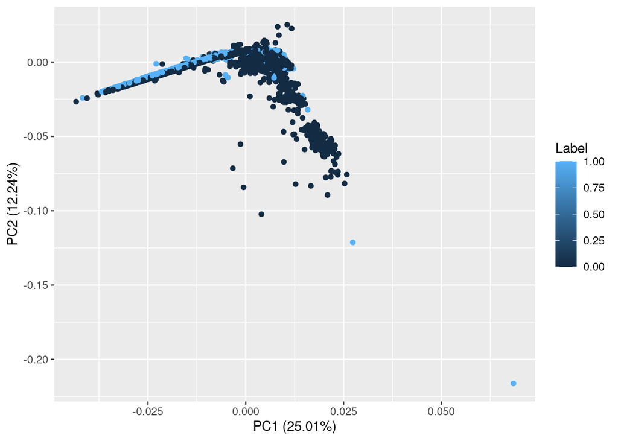

```r
autoplot(pcas, data = events, colour = 'Label')
```

## APPLY PCA

Reemplazamos los valores de PCA en el dataframe

```
##   proto Label        PC1        PC2         PC3         PC4         PC5
## 1   tcp     0  1.8893803 -0.4963304  0.40824711  0.05865451 -1.29032065
## 2   tcp     0  1.7765191 -0.7196867  0.28673941  0.09459218  2.47209484
## 3   tcp     0  2.2115605  0.1697937 -0.02719163 -0.66363763  1.63024535
## 4   udp     0  0.1083293  1.7478425 -0.87803409 -1.85881160 -0.03757666
## 5   tcp     0  0.3957092  1.3685202  5.91444473 -0.04481254  0.50339634
## 6   udp     0 -0.7435985  1.3951822 -0.25969274 -1.60160819 -0.11852215
##           PC6         PC7        PC8        PC9       PC10
## 1 -0.02919425  0.59058660  1.4584165  0.1906231 -0.5180091
## 2  2.60962315  4.87658239 -1.3762055  1.2395499  0.4130596
## 3  1.43200412  3.27514423 -1.2032840  0.4923600  0.6110254
## 4 -1.22517713 -0.02058627 -1.5311204 -0.2102728  0.1254585
## 5 -1.03232834 -0.63362826  0.4875152  0.5202057  1.1755651
## 6 -1.38075125  0.16510295  0.9509870 -0.4305013 -0.6112075
```

## Feature engineering

```
##
## ATTACK NORMAL
## 0.1251 0.8749
```

## Build model

### Create train and test data sets

### Train model

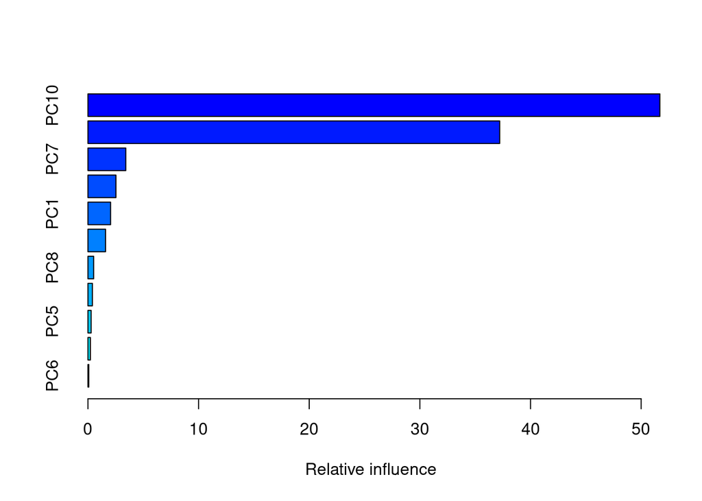

```
##         var     rel.inf
## PC10   PC10 51.69356975
## PC3     PC3 37.21670331
## PC7     PC7  3.42091253
## proto proto  2.52982504
## PC1     PC1  2.04553408
## PC9     PC9  1.59052786
## PC8     PC8  0.51633230
## PC4     PC4  0.39975894
## PC5     PC5  0.28950493
## PC2     PC2  0.21961987
## PC6     PC6  0.07771141
```

### Test model

```
## [1] NORMAL NORMAL NORMAL NORMAL NORMAL NORMAL
## Levels: ATTACK NORMAL
```

## Evaluate model

```
##  Accuracy     Kappa
## 0.9867947 0.9404705
```

```r
# probabilites
predictions <- predict(object=objModel, testDF[,predictorsNames], type='prob')
auc <- roc(ifelse(testDF[,outcomeName]=="ATTACK",1,0), predictions[[2]])
print(auc$auc)
```

```
## Area under the curve: 0.9989
```

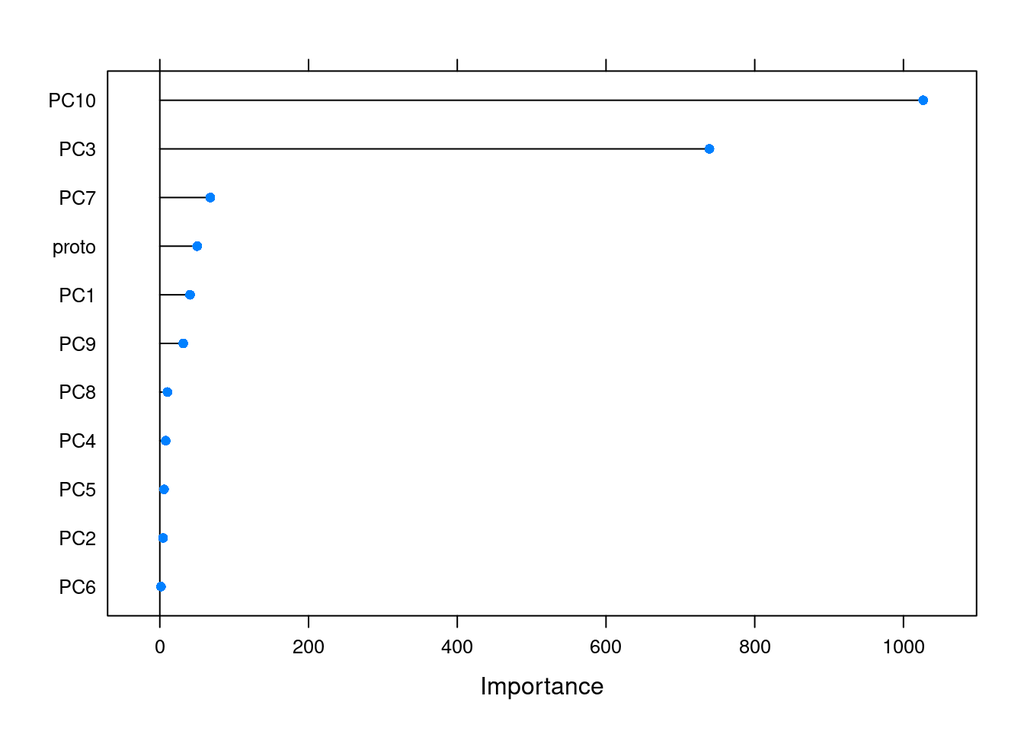

```r
plot(varImp(objModel,scale=F))
```

## Conclusion

Realizando la reduccion por pca, y utilizando los 10 primeros pcs y el protocolo. Obtendremos,según los test, un Accuracy del 98%.